# Risk Factor Analysis

## Outcome Variable

**Outcome Variable:** stunted

## Predictor Variables

**Intervention Variable:** predexfd6

**Adjustment Set:**

- arm
- sex
- brthmon
- W_mage
- meducyrs
- feducyrs
- hhwealth_quart
- hfoodsec
- W_mhtcm
- W_mwtkg
- W_mbmi
- vagbrth
- W_gagebrth
- W_birthwt
- W_birthlen
- W_nrooms
- W_nchldlt5
- month
- W_parity
- impfloor
- impsan
- safeh20
- delta_W_mage
- delta_meducyrs
- delta_feducyrs
- delta_hhwealth_quart
- delta_hfoodsec
- delta_W_mhtcm
- delta_W_mwtkg
- delta_W_mbmi
- delta_vagbrth
- delta_W_gagebrth
- delta_W_birthwt
- delta_W_birthlen
- delta_W_nrooms
- delta_W_nchldlt5
- delta_month
- delta_W_parity
- delta_impfloor
- delta_impsan
- delta_safeh20

## Stratifying Variables

The analysis was stratified on these variable(s):

- agecat
- studyid
- country

## Data Summary

| agecat | studyid | country | predexfd6 | stunted | n_cell | n |
| --- | --- | --- | --- | --- | --- | --- |
| Birth | CMC-V-BCS-2002 | INDIA | 1 | 0 | 7 | 7 |
| Birth | CMC-V-BCS-2002 | INDIA | 1 | 1 | 0 | 7 |
| Birth | CMC-V-BCS-2002 | INDIA | 0 | 0 | 0 | 7 |
| Birth | CMC-V-BCS-2002 | INDIA | 0 | 1 | 0 | 7 |
| Birth | EE | PAKISTAN | 1 | 0 | 22 | 42 |
| Birth | EE | PAKISTAN | 1 | 1 | 16 | 42 |
| Birth | EE | PAKISTAN | 0 | 0 | 3 | 42 |
| Birth | EE | PAKISTAN | 0 | 1 | 1 | 42 |
| Birth | GMS-Nepal | NEPAL | 1 | 0 | 351 | 563 |
| Birth | GMS-Nepal | NEPAL | 1 | 1 | 68 | 563 |
| Birth | GMS-Nepal | NEPAL | 0 | 0 | 118 | 563 |
| Birth | GMS-Nepal | NEPAL | 0 | 1 | 26 | 563 |
| Birth | IRC | INDIA | 1 | 0 | 0 | 14 |
| Birth | IRC | INDIA | 1 | 1 | 0 | 14 |
| Birth | IRC | INDIA | 0 | 0 | 13 | 14 |
| Birth | IRC | INDIA | 0 | 1 | 1 | 14 |
| Birth | JiVitA-3 | BANGLADESH | 1 | 0 | 7012 | 13423 |
| Birth | JiVitA-3 | BANGLADESH | 1 | 1 | 3454 | 13423 |
| Birth | JiVitA-3 | BANGLADESH | 0 | 0 | 1967 | 13423 |
| Birth | JiVitA-3 | BANGLADESH | 0 | 1 | 990 | 13423 |
| Birth | JiVitA-4 | BANGLADESH | 1 | 0 | 1479 | 2632 |
| Birth | JiVitA-4 | BANGLADESH | 1 | 1 | 624 | 2632 |
| Birth | JiVitA-4 | BANGLADESH | 0 | 0 | 354 | 2632 |
| Birth | JiVitA-4 | BANGLADESH | 0 | 1 | 175 | 2632 |
| Birth | Keneba | GAMBIA | 1 | 0 | 459 | 1403 |
| Birth | Keneba | GAMBIA | 1 | 1 | 26 | 1403 |
| Birth | Keneba | GAMBIA | 0 | 0 | 865 | 1403 |
| Birth | Keneba | GAMBIA | 0 | 1 | 53 | 1403 |
| Birth | MAL-ED | BANGLADESH | 1 | 0 | 60 | 205 |
| Birth | MAL-ED | BANGLADESH | 1 | 1 | 12 | 205 |

[output cut: 170 more lines]

The following strata were considered:

- agecat: 24 months, studyid: CMC-V-BCS-2002, country: INDIA
- agecat: 24 months, studyid: EE, country: PAKISTAN
- agecat: 24 months, studyid: GMS-Nepal, country: NEPAL
- agecat: 24 months, studyid: IRC, country: INDIA
- agecat: 24 months, studyid: JiVitA-3, country: BANGLADESH
- agecat: 24 months, studyid: JiVitA-4, country: BANGLADESH
- agecat: 24 months, studyid: Keneba, country: GAMBIA
- agecat: 24 months, studyid: LCNI-5, country: MALAWI
- agecat: 24 months, studyid: MAL-ED, country: BANGLADESH
- agecat: 24 months, studyid: MAL-ED, country: BRAZIL
- agecat: 24 months, studyid: MAL-ED, country: INDIA
- agecat: 24 months, studyid: MAL-ED, country: NEPAL
- agecat: 24 months, studyid: MAL-ED, country: PERU
- agecat: 24 months, studyid: MAL-ED, country: SOUTH AFRICA
- agecat: 24 months, studyid: MAL-ED, country: TANZANIA, UNITED REPUBLIC OF
- agecat: 24 months, studyid: PROVIDE, country: BANGLADESH
- agecat: 6 months, studyid: CMC-V-BCS-2002, country: INDIA
- agecat: 6 months, studyid: EE, country: PAKISTAN
- agecat: 6 months, studyid: GMS-Nepal, country: NEPAL
- agecat: 6 months, studyid: IRC, country: INDIA
- agecat: 6 months, studyid: JiVitA-3, country: BANGLADESH
- agecat: 6 months, studyid: JiVitA-4, country: BANGLADESH
- agecat: 6 months, studyid: Keneba, country: GAMBIA
- agecat: 6 months, studyid: LCNI-5, country: MALAWI
- agecat: 6 months, studyid: MAL-ED, country: BANGLADESH
- agecat: 6 months, studyid: MAL-ED, country: BRAZIL
- agecat: 6 months, studyid: MAL-ED, country: INDIA
- agecat: 6 months, studyid: MAL-ED, country: NEPAL
- agecat: 6 months, studyid: MAL-ED, country: PERU
- agecat: 6 months, studyid: MAL-ED, country: SOUTH AFRICA
- agecat: 6 months, studyid: MAL-ED, country: TANZANIA, UNITED REPUBLIC OF
- agecat: 6 months, studyid: PROVIDE, country: BANGLADESH
- agecat: 6 months, studyid: SAS-CompFeed, country: INDIA
- agecat: 6 months, studyid: SAS-FoodSuppl, country: INDIA
- agecat: Birth, studyid: CMC-V-BCS-2002, country: INDIA
- agecat: Birth, studyid: EE, country: PAKISTAN
- agecat: Birth, studyid: GMS-Nepal, country: NEPAL
- agecat: Birth, studyid: IRC, country: INDIA
- agecat: Birth, studyid: JiVitA-3, country: BANGLADESH
- agecat: Birth, studyid: JiVitA-4, country: BANGLADESH
- agecat: Birth, studyid: Keneba, country: GAMBIA
- agecat: Birth, studyid: MAL-ED, country: BANGLADESH
- agecat: Birth, studyid: MAL-ED, country: BRAZIL
- agecat: Birth, studyid: MAL-ED, country: INDIA
- agecat: Birth, studyid: MAL-ED, country: NEPAL
- agecat: Birth, studyid: MAL-ED, country: PERU
- agecat: Birth, studyid: MAL-ED, country: SOUTH AFRICA
- agecat: Birth, studyid: MAL-ED, country: TANZANIA, UNITED REPUBLIC OF
- agecat: Birth, studyid: PROVIDE, country: BANGLADESH
- agecat: Birth, studyid: SAS-CompFeed, country: INDIA

### Dropped Strata

Some strata were dropped due to rare outcomes:

- agecat: Birth, studyid: CMC-V-BCS-2002, country: INDIA
- agecat: Birth, studyid: EE, country: PAKISTAN
- agecat: Birth, studyid: IRC, country: INDIA
- agecat: Birth, studyid: MAL-ED, country: BRAZIL
- agecat: Birth, studyid: MAL-ED, country: INDIA
- agecat: Birth, studyid: MAL-ED, country: NEPAL
- agecat: Birth, studyid: MAL-ED, country: SOUTH AFRICA
- agecat: Birth, studyid: MAL-ED, country: TANZANIA, UNITED REPUBLIC OF
- agecat: 6 months, studyid: CMC-V-BCS-2002, country: INDIA
- agecat: 6 months, studyid: EE, country: PAKISTAN
- agecat: 6 months, studyid: IRC, country: INDIA
- agecat: 6 months, studyid: MAL-ED, country: BRAZIL
- agecat: 6 months, studyid: MAL-ED, country: INDIA
- agecat: 6 months, studyid: MAL-ED, country: NEPAL
- agecat: 6 months, studyid: MAL-ED, country: SOUTH AFRICA
- agecat: 6 months, studyid: MAL-ED, country: TANZANIA, UNITED REPUBLIC OF
- agecat: 6 months, studyid: SAS-FoodSuppl, country: INDIA
- agecat: 24 months, studyid: CMC-V-BCS-2002, country: INDIA
- agecat: 24 months, studyid: EE, country: PAKISTAN
- agecat: 24 months, studyid: IRC, country: INDIA
- agecat: 24 months, studyid: MAL-ED, country: BRAZIL
- agecat: 24 months, studyid: MAL-ED, country: INDIA
- agecat: 24 months, studyid: MAL-ED, country: NEPAL
- agecat: 24 months, studyid: MAL-ED, country: SOUTH AFRICA
- agecat: 24 months, studyid: MAL-ED, country: TANZANIA, UNITED REPUBLIC OF

## Methods Detail

We’re interested in the causal parameters $E[Y_a]$ for all values of $a \in \mathcal{A}$. These parameters represent the mean outcome if, possibly contrary to fact, we intervened to set all units to have $A=a$. Under the randomization and positivity assumptions, these are identified by the statistical parameters $\psi_a=E_W[E_{Y|A,W}(Y|A=a,W)]$. In addition, we’re interested in the mean of $Y$, $E[Y]$ under no intervention (the observed mean). We will estimate these parameters by using SuperLearner to fit the relevant likelihood factors – $E_{Y|A,W}(Y|A=a,W)$ and $p(A=a|W)$, and then updating our likelihood fit using a joint TMLE.

For unadjusted analyses ($W=\{\}$), initial likelihoods were estimated using Lrnr_glm to estimate the simple $E(Y|A)$ and Lrnr_mean to estimate $p(A)$. For adjusted analyses, a small library containing Lrnr_glmnet, Lrnr_xgboost, and Lrnr_mean was used.

Having estimated these parameters, we will then use the delta method to estimate relative risks and attributable risks relative to a prespecified baseline level of $A$.

# Results Detail

## Results Plots

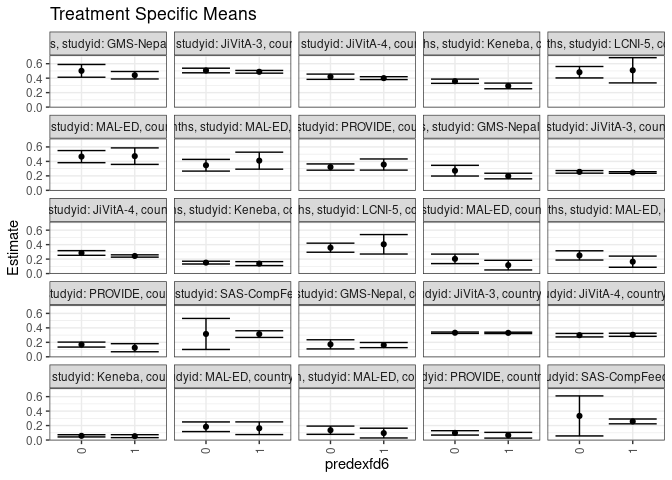

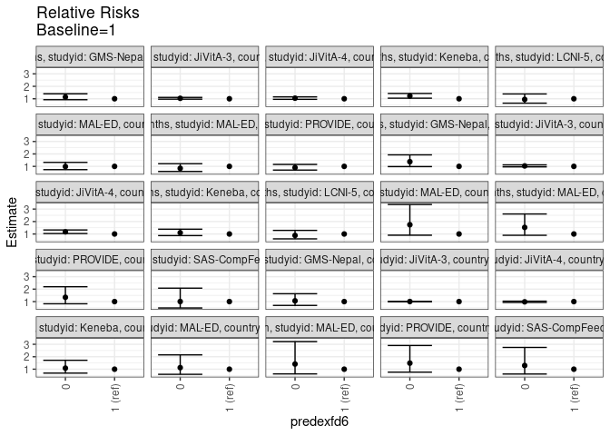

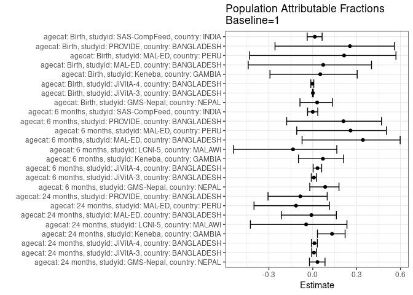

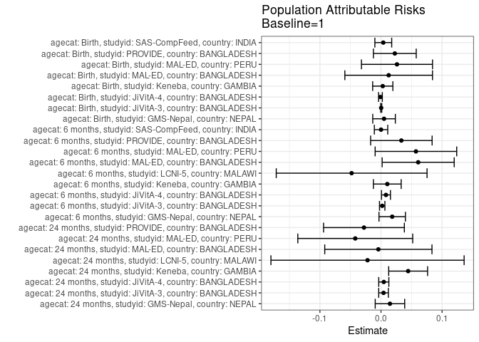

## Results Table

### Parameter: TSM

| agecat | studyid | country | intervention_level | baseline_level | estimate | ci_lower | ci_upper |
| --- | --- | --- | --- | --- | --- | --- | --- |
| Birth | GMS-Nepal | NEPAL | 1 | NA | 0.1619641 | 0.1265994 | 0.1973289 |
| Birth | GMS-Nepal | NEPAL | 0 | NA | 0.1721145 | 0.1085724 | 0.2356566 |
| Birth | JiVitA-3 | BANGLADESH | 1 | NA | 0.3307341 | 0.3214849 | 0.3399833 |
| Birth | JiVitA-3 | BANGLADESH | 0 | NA | 0.3323437 | 0.3226524 | 0.3420350 |
| Birth | JiVitA-4 | BANGLADESH | 1 | NA | 0.3044427 | 0.2829304 | 0.3259550 |
| Birth | JiVitA-4 | BANGLADESH | 0 | NA | 0.2986379 | 0.2745671 | 0.3227086 |
| Birth | Keneba | GAMBIA | 1 | NA | 0.0534096 | 0.0332699 | 0.0735493 |
| Birth | Keneba | GAMBIA | 0 | NA | 0.0578921 | 0.0427167 | 0.0730676 |
| Birth | MAL-ED | BANGLADESH | 1 | NA | 0.1630332 | 0.0756616 | 0.2504048 |
| Birth | MAL-ED | BANGLADESH | 0 | NA | 0.1833021 | 0.1164148 | 0.2501893 |
| Birth | MAL-ED | PERU | 1 | NA | 0.0958904 | 0.0281876 | 0.1635932 |
| Birth | MAL-ED | PERU | 0 | NA | 0.1357143 | 0.0788490 | 0.1925796 |
| Birth | PROVIDE | BANGLADESH | 1 | NA | 0.0664013 | 0.0267644 | 0.1060383 |
| Birth | PROVIDE | BANGLADESH | 0 | NA | 0.0987563 | 0.0686844 | 0.1288282 |
| Birth | SAS-CompFeed | INDIA | 1 | NA | 0.2572254 | 0.2236819 | 0.2907690 |
| Birth | SAS-CompFeed | INDIA | 0 | NA | 0.3333333 | 0.0564891 | 0.6101775 |
| 6 months | GMS-Nepal | NEPAL | 1 | NA | 0.1973712 | 0.1586349 | 0.2361076 |
| 6 months | GMS-Nepal | NEPAL | 0 | NA | 0.2715747 | 0.1977093 | 0.3454401 |
| 6 months | JiVitA-3 | BANGLADESH | 1 | NA | 0.2462800 | 0.2353314 | 0.2572287 |
| 6 months | JiVitA-3 | BANGLADESH | 0 | NA | 0.2552478 | 0.2372730 | 0.2732225 |
| 6 months | JiVitA-4 | BANGLADESH | 1 | NA | 0.2430428 | 0.2270786 | 0.2590070 |
| 6 months | JiVitA-4 | BANGLADESH | 0 | NA | 0.2845527 | 0.2526034 | 0.3165020 |
| 6 months | Keneba | GAMBIA | 1 | NA | 0.1374991 | 0.1101026 | 0.1648957 |
| 6 months | Keneba | GAMBIA | 0 | NA | 0.1511425 | 0.1320712 | 0.1702137 |
| 6 months | LCNI-5 | MALAWI | 1 | NA | 0.4046484 | 0.2701850 | 0.5391117 |
| 6 months | LCNI-5 | MALAWI | 0 | NA | 0.3576207 | 0.2949319 | 0.4203094 |
| 6 months | MAL-ED | BANGLADESH | 1 | NA | 0.1165896 | 0.0496416 | 0.1835376 |
| 6 months | MAL-ED | BANGLADESH | 0 | NA | 0.2032520 | 0.1377242 | 0.2687798 |
| 6 months | MAL-ED | PERU | 1 | NA | 0.1642068 | 0.0870397 | 0.2413739 |
| 6 months | MAL-ED | PERU | 0 | NA | 0.2508934 | 0.1871252 | 0.3146615 |
| 6 months | PROVIDE | BANGLADESH | 1 | NA | 0.1255814 | 0.0696663 | 0.1814964 |
| 6 months | PROVIDE | BANGLADESH | 0 | NA | 0.1687243 | 0.1345956 | 0.2028529 |
| 6 months | SAS-CompFeed | INDIA | 1 | NA | 0.3139842 | 0.2679102 | 0.3600581 |
| 6 months | SAS-CompFeed | INDIA | 0 | NA | 0.3157895 | 0.1014523 | 0.5301266 |
| 24 months | GMS-Nepal | NEPAL | 1 | NA | 0.4406426 | 0.3891915 | 0.4920937 |
| 24 months | GMS-Nepal | NEPAL | 0 | NA | 0.5013070 | 0.4131890 | 0.5894251 |
| 24 months | JiVitA-3 | BANGLADESH | 1 | NA | 0.4879499 | 0.4692501 | 0.5066497 |
| 24 months | JiVitA-3 | BANGLADESH | 0 | NA | 0.5058075 | 0.4740148 | 0.5376002 |
| 24 months | JiVitA-4 | BANGLADESH | 1 | NA | 0.4004869 | 0.3808767 | 0.4200971 |
| 24 months | JiVitA-4 | BANGLADESH | 0 | NA | 0.4197776 | 0.3831761 | 0.4563790 |
| 24 months | Keneba | GAMBIA | 1 | NA | 0.2926201 | 0.2536842 | 0.3315560 |
| 24 months | Keneba | GAMBIA | 0 | NA | 0.3575712 | 0.3283592 | 0.3867831 |
| 24 months | LCNI-5 | MALAWI | 1 | NA | 0.5088025 | 0.3344002 | 0.6832047 |
| 24 months | LCNI-5 | MALAWI | 0 | NA | 0.4822274 | 0.4031709 | 0.5612839 |
| 24 months | MAL-ED | BANGLADESH | 1 | NA | 0.4726025 | 0.3585520 | 0.5866531 |
| 24 months | MAL-ED | BANGLADESH | 0 | NA | 0.4662255 | 0.3825778 | 0.5498731 |
| 24 months | MAL-ED | PERU | 1 | NA | 0.4102865 | 0.2927727 | 0.5278003 |
| 24 months | MAL-ED | PERU | 0 | NA | 0.3466989 | 0.2659421 | 0.4274557 |
| 24 months | PROVIDE | BANGLADESH | 1 | NA | 0.3565682 | 0.2796150 | 0.4335213 |
| 24 months | PROVIDE | BANGLADESH | 0 | NA | 0.3217625 | 0.2785226 | 0.3650025 |

### Parameter: E(Y)

| agecat | studyid | country | intervention_level | baseline_level | estimate | ci_lower | ci_upper |
| --- | --- | --- | --- | --- | --- | --- | --- |
| Birth | GMS-Nepal | NEPAL | NA | NA | 0.1669627 | 0.1361293 | 0.1977961 |
| Birth | JiVitA-3 | BANGLADESH | NA | NA | 0.3310735 | 0.3218922 | 0.3402548 |
| Birth | JiVitA-4 | BANGLADESH | NA | NA | 0.3035714 | 0.2824097 | 0.3247332 |
| Birth | Keneba | GAMBIA | NA | NA | 0.0563079 | 0.0442416 | 0.0683742 |
| Birth | MAL-ED | BANGLADESH | NA | NA | 0.1756098 | 0.1233973 | 0.2278222 |
| Birth | MAL-ED | PERU | NA | NA | 0.1220657 | 0.0779993 | 0.1661322 |
| Birth | PROVIDE | BANGLADESH | NA | NA | 0.0890538 | 0.0649864 | 0.1131212 |
| Birth | SAS-CompFeed | INDIA | NA | NA | 0.2609890 | 0.2179233 | 0.3040547 |
| 6 months | GMS-Nepal | NEPAL | NA | NA | 0.2157221 | 0.1812209 | 0.2502233 |
| 6 months | JiVitA-3 | BANGLADESH | NA | NA | 0.2482578 | 0.2382387 | 0.2582768 |
| 6 months | JiVitA-4 | BANGLADESH | NA | NA | 0.2511704 | 0.2362353 | 0.2661055 |
| 6 months | Keneba | GAMBIA | NA | NA | 0.1477987 | 0.1318701 | 0.1637274 |
| 6 months | LCNI-5 | MALAWI | NA | NA | 0.3566176 | 0.2995882 | 0.4136471 |
| 6 months | MAL-ED | BANGLADESH | NA | NA | 0.1774892 | 0.1281103 | 0.2268680 |
| 6 months | MAL-ED | PERU | NA | NA | 0.2214022 | 0.1718784 | 0.2709260 |
| 6 months | PROVIDE | BANGLADESH | NA | NA | 0.1589404 | 0.1297581 | 0.1881227 |
| 6 months | SAS-CompFeed | INDIA | NA | NA | 0.3140704 | 0.2712850 | 0.3568557 |
| 24 months | GMS-Nepal | NEPAL | NA | NA | 0.4553191 | 0.4102488 | 0.5003895 |
| 24 months | JiVitA-3 | BANGLADESH | NA | NA | 0.4921384 | 0.4750959 | 0.5091808 |
| 24 months | JiVitA-4 | BANGLADESH | NA | NA | 0.4050965 | 0.3867240 | 0.4234689 |
| 24 months | Keneba | GAMBIA | NA | NA | 0.3370787 | 0.3132517 | 0.3609056 |
| 24 months | LCNI-5 | MALAWI | NA | NA | 0.4867725 | 0.4153250 | 0.5582200 |
| 24 months | MAL-ED | BANGLADESH | NA | NA | 0.4682927 | 0.3998183 | 0.5367670 |
| 24 months | MAL-ED | PERU | NA | NA | 0.3681592 | 0.3013164 | 0.4350020 |
| 24 months | PROVIDE | BANGLADESH | NA | NA | 0.3287197 | 0.2903909 | 0.3670485 |

### Parameter: RR

| agecat | studyid | country | intervention_level | baseline_level | estimate | ci_lower | ci_upper |
| --- | --- | --- | --- | --- | --- | --- | --- |
| Birth | GMS-Nepal | NEPAL | 1 | 1 | 1.0000000 | 1.0000000 | 1.000000 |
| Birth | GMS-Nepal | NEPAL | 0 | 1 | 1.0626706 | 0.6918010 | 1.632361 |
| Birth | JiVitA-3 | BANGLADESH | 1 | 1 | 1.0000000 | 1.0000000 | 1.000000 |
| Birth | JiVitA-3 | BANGLADESH | 0 | 1 | 1.0048668 | 0.9922151 | 1.017680 |
| Birth | JiVitA-4 | BANGLADESH | 1 | 1 | 1.0000000 | 1.0000000 | 1.000000 |
| Birth | JiVitA-4 | BANGLADESH | 0 | 1 | 0.9809329 | 0.9317633 | 1.032697 |
| Birth | Keneba | GAMBIA | 1 | 1 | 1.0000000 | 1.0000000 | 1.000000 |
| Birth | Keneba | GAMBIA | 0 | 1 | 1.0839269 | 0.6848573 | 1.715536 |
| Birth | MAL-ED | BANGLADESH | 1 | 1 | 1.0000000 | 1.0000000 | 1.000000 |
| Birth | MAL-ED | BANGLADESH | 0 | 1 | 1.1243234 | 0.5883498 | 2.148557 |
| Birth | MAL-ED | PERU | 1 | 1 | 1.0000000 | 1.0000000 | 1.000000 |
| Birth | MAL-ED | PERU | 0 | 1 | 1.4153061 | 0.6227136 | 3.216714 |
| Birth | PROVIDE | BANGLADESH | 1 | 1 | 1.0000000 | 1.0000000 | 1.000000 |
| Birth | PROVIDE | BANGLADESH | 0 | 1 | 1.4872637 | 0.7620350 | 2.902693 |
| Birth | SAS-CompFeed | INDIA | 1 | 1 | 1.0000000 | 1.0000000 | 1.000000 |
| Birth | SAS-CompFeed | INDIA | 0 | 1 | 1.2958801 | 0.6113712 | 2.746785 |
| 6 months | GMS-Nepal | NEPAL | 1 | 1 | 1.0000000 | 1.0000000 | 1.000000 |
| 6 months | GMS-Nepal | NEPAL | 0 | 1 | 1.3759588 | 0.9833439 | 1.925331 |
| 6 months | JiVitA-3 | BANGLADESH | 1 | 1 | 1.0000000 | 1.0000000 | 1.000000 |
| 6 months | JiVitA-3 | BANGLADESH | 0 | 1 | 1.0364127 | 0.9601990 | 1.118676 |
| 6 months | JiVitA-4 | BANGLADESH | 1 | 1 | 1.0000000 | 1.0000000 | 1.000000 |
| 6 months | JiVitA-4 | BANGLADESH | 0 | 1 | 1.1707926 | 1.0359532 | 1.323183 |
| 6 months | Keneba | GAMBIA | 1 | 1 | 1.0000000 | 1.0000000 | 1.000000 |
| 6 months | Keneba | GAMBIA | 0 | 1 | 1.0992248 | 0.8711989 | 1.386934 |
| 6 months | LCNI-5 | MALAWI | 1 | 1 | 1.0000000 | 1.0000000 | 1.000000 |
| 6 months | LCNI-5 | MALAWI | 0 | 1 | 0.8837813 | 0.6063450 | 1.288160 |
| 6 months | MAL-ED | BANGLADESH | 1 | 1 | 1.0000000 | 1.0000000 | 1.000000 |
| 6 months | MAL-ED | BANGLADESH | 0 | 1 | 1.7433115 | 0.9025328 | 3.367340 |
| 6 months | MAL-ED | PERU | 1 | 1 | 1.0000000 | 1.0000000 | 1.000000 |
| 6 months | MAL-ED | PERU | 0 | 1 | 1.5279108 | 0.8951793 | 2.607870 |
| 6 months | PROVIDE | BANGLADESH | 1 | 1 | 1.0000000 | 1.0000000 | 1.000000 |
| 6 months | PROVIDE | BANGLADESH | 0 | 1 | 1.3435453 | 0.8243843 | 2.189651 |
| 6 months | SAS-CompFeed | INDIA | 1 | 1 | 1.0000000 | 1.0000000 | 1.000000 |
| 6 months | SAS-CompFeed | INDIA | 0 | 1 | 1.0057497 | 0.4866253 | 2.078668 |
| 24 months | GMS-Nepal | NEPAL | 1 | 1 | 1.0000000 | 1.0000000 | 1.000000 |
| 24 months | GMS-Nepal | NEPAL | 0 | 1 | 1.1376727 | 0.9249649 | 1.399295 |
| 24 months | JiVitA-3 | BANGLADESH | 1 | 1 | 1.0000000 | 1.0000000 | 1.000000 |
| 24 months | JiVitA-3 | BANGLADESH | 0 | 1 | 1.0365972 | 0.9675821 | 1.110535 |
| 24 months | JiVitA-4 | BANGLADESH | 1 | 1 | 1.0000000 | 1.0000000 | 1.000000 |
| 24 months | JiVitA-4 | BANGLADESH | 0 | 1 | 1.0481681 | 0.9551244 | 1.150276 |
| 24 months | Keneba | GAMBIA | 1 | 1 | 1.0000000 | 1.0000000 | 1.000000 |
| 24 months | Keneba | GAMBIA | 0 | 1 | 1.2219637 | 1.0479209 | 1.424912 |
| 24 months | LCNI-5 | MALAWI | 1 | 1 | 1.0000000 | 1.0000000 | 1.000000 |
| 24 months | LCNI-5 | MALAWI | 0 | 1 | 0.9477694 | 0.6480668 | 1.386071 |
| 24 months | MAL-ED | BANGLADESH | 1 | 1 | 1.0000000 | 1.0000000 | 1.000000 |
| 24 months | MAL-ED | BANGLADESH | 0 | 1 | 0.9865065 | 0.7359850 | 1.322303 |
| 24 months | MAL-ED | PERU | 1 | 1 | 1.0000000 | 1.0000000 | 1.000000 |
| 24 months | MAL-ED | PERU | 0 | 1 | 0.8450166 | 0.5884417 | 1.213464 |
| 24 months | PROVIDE | BANGLADESH | 1 | 1 | 1.0000000 | 1.0000000 | 1.000000 |
| 24 months | PROVIDE | BANGLADESH | 0 | 1 | 0.9023872 | 0.7034275 | 1.157621 |

### Parameter: PAR

| agecat | studyid | country | intervention_level | baseline_level | estimate | ci_lower | ci_upper |
| --- | --- | --- | --- | --- | --- | --- | --- |
| Birth | GMS-Nepal | NEPAL | 1 | NA | 0.0049986 | -0.0134966 | 0.0234937 |
| Birth | JiVitA-3 | BANGLADESH | 1 | NA | 0.0003394 | -0.0005919 | 0.0012708 |
| Birth | JiVitA-4 | BANGLADESH | 1 | NA | -0.0008713 | -0.0039384 | 0.0021959 |
| Birth | Keneba | GAMBIA | 1 | NA | 0.0028983 | -0.0136336 | 0.0194302 |
| Birth | MAL-ED | BANGLADESH | 1 | NA | 0.0125765 | -0.0591484 | 0.0843015 |
| Birth | MAL-ED | PERU | 1 | NA | 0.0261753 | -0.0319939 | 0.0843446 |
| Birth | PROVIDE | BANGLADESH | 1 | NA | 0.0226525 | -0.0124028 | 0.0577078 |
| Birth | SAS-CompFeed | INDIA | 1 | NA | 0.0037636 | -0.0100156 | 0.0175428 |
| 6 months | GMS-Nepal | NEPAL | 1 | NA | 0.0183509 | -0.0032695 | 0.0399713 |
| 6 months | JiVitA-3 | BANGLADESH | 1 | NA | 0.0019777 | -0.0024318 | 0.0063873 |
| 6 months | JiVitA-4 | BANGLADESH | 1 | NA | 0.0081276 | 0.0007734 | 0.0154819 |
| 6 months | Keneba | GAMBIA | 1 | NA | 0.0102996 | -0.0124284 | 0.0330276 |
| 6 months | LCNI-5 | MALAWI | 1 | NA | -0.0480307 | -0.1714529 | 0.0753915 |
| 6 months | MAL-ED | BANGLADESH | 1 | NA | 0.0608996 | 0.0019265 | 0.1198726 |
| 6 months | MAL-ED | PERU | 1 | NA | 0.0571954 | -0.0095492 | 0.1239400 |
| 6 months | PROVIDE | BANGLADESH | 1 | NA | 0.0333590 | -0.0169742 | 0.0836922 |
| 6 months | SAS-CompFeed | INDIA | 1 | NA | 0.0000862 | -0.0108674 | 0.0110398 |
| 24 months | GMS-Nepal | NEPAL | 1 | NA | 0.0146765 | -0.0094420 | 0.0387951 |
| 24 months | JiVitA-3 | BANGLADESH | 1 | NA | 0.0041885 | -0.0037065 | 0.0120835 |
| 24 months | JiVitA-4 | BANGLADESH | 1 | NA | 0.0046096 | -0.0036582 | 0.0128774 |
| 24 months | Keneba | GAMBIA | 1 | NA | 0.0444585 | 0.0126377 | 0.0762794 |
| 24 months | LCNI-5 | MALAWI | 1 | NA | -0.0220300 | -0.1801542 | 0.1360942 |
| 24 months | MAL-ED | BANGLADESH | 1 | NA | -0.0043098 | -0.0920675 | 0.0834478 |
| 24 months | MAL-ED | PERU | 1 | NA | -0.0421273 | -0.1361638 | 0.0519092 |
| 24 months | PROVIDE | BANGLADESH | 1 | NA | -0.0278484 | -0.0939741 | 0.0382772 |

### Parameter: PAF

| agecat | studyid | country | intervention_level | baseline_level | estimate | ci_lower | ci_upper |
| --- | --- | --- | --- | --- | --- | --- | --- |
| Birth | GMS-Nepal | NEPAL | 1 | NA | 0.0299383 | -0.0873343 | 0.1345627 |
| Birth | JiVitA-3 | BANGLADESH | 1 | NA | 0.0010252 | -0.0017926 | 0.0038351 |
| Birth | JiVitA-4 | BANGLADESH | 1 | NA | -0.0028701 | -0.0130181 | 0.0071762 |
| Birth | Keneba | GAMBIA | 1 | NA | 0.0514718 | -0.2924214 | 0.3038604 |
| Birth | MAL-ED | BANGLADESH | 1 | NA | 0.0716164 | -0.4412389 | 0.4019755 |
| Birth | MAL-ED | PERU | 1 | NA | 0.2144362 | -0.4318688 | 0.5690175 |
| Birth | PROVIDE | BANGLADESH | 1 | NA | 0.2543683 | -0.2579507 | 0.5580378 |
| Birth | SAS-CompFeed | INDIA | 1 | NA | 0.0144204 | -0.0378960 | 0.0640998 |
| 6 months | GMS-Nepal | NEPAL | 1 | NA | 0.0850672 | -0.0202804 | 0.1795373 |
| 6 months | JiVitA-3 | BANGLADESH | 1 | NA | 0.0079664 | -0.0099587 | 0.0255734 |
| 6 months | JiVitA-4 | BANGLADESH | 1 | NA | 0.0323590 | 0.0027679 | 0.0610721 |
| 6 months | Keneba | GAMBIA | 1 | NA | 0.0696866 | -0.0975046 | 0.2114083 |
| 6 months | LCNI-5 | MALAWI | 1 | NA | -0.1346840 | -0.5411052 | 0.1645555 |
| 6 months | MAL-ED | BANGLADESH | 1 | NA | 0.3431170 | -0.0729740 | 0.5978511 |
| 6 months | MAL-ED | PERU | 1 | NA | 0.2583326 | -0.1094165 | 0.5041804 |
| 6 months | PROVIDE | BANGLADESH | 1 | NA | 0.2098838 | -0.1780953 | 0.4700908 |
| 6 months | SAS-CompFeed | INDIA | 1 | NA | 0.0002744 | -0.0352245 | 0.0345560 |
| 24 months | GMS-Nepal | NEPAL | 1 | NA | 0.0322335 | -0.0223678 | 0.0839188 |
| 24 months | JiVitA-3 | BANGLADESH | 1 | NA | 0.0085108 | -0.0076611 | 0.0244232 |
| 24 months | JiVitA-4 | BANGLADESH | 1 | NA | 0.0113790 | -0.0092122 | 0.0315500 |
| 24 months | Keneba | GAMBIA | 1 | NA | 0.1318937 | 0.0320952 | 0.2214022 |
| 24 months | LCNI-5 | MALAWI | 1 | NA | -0.0452573 | -0.4262070 | 0.2339381 |
| 24 months | MAL-ED | BANGLADESH | 1 | NA | -0.0092033 | -0.2150529 | 0.1617721 |
| 24 months | MAL-ED | PERU | 1 | NA | -0.1144269 | -0.4015181 | 0.1138557 |
| 24 months | PROVIDE | BANGLADESH | 1 | NA | -0.0847179 | -0.3058442 | 0.0989639 |